## Course: VISUAL ANALYTICS FOR POLICY AND MANAGEMENT

### Prof. José Manuel Magallanes, PhD

- Visiting Professor of Computational Policy at Evans School of Public Policy and Governance, and eScience Institute Senior Data Science Fellow, University of Washington.
- Professor of Government and Political Methodology, Pontificia Universidad Católica del Perú.

# Tabular data - Bivariate relationships I: Categorical-Categorical

We analyze two variables to find out if there might be some kind of association between them. Even though that may be difficult to clearly identify, bivariate analysis still helps reveal *signs* of association that may serve at least to raise concern.

As before, the nature of the data allows for some particular analytical techniques, while also providing some limitations to our inferences. Let’s see what we can visualize with the different combinations of data.

This time, I will use the [data about crime](https://data.seattle.gov/Public-Safety/Crime-Data/4fs7-3vj5) from the Seattle Open Data portal. The file has been previously prepared and consists of around half a million rows:

```r
# collecting the data
link="https://github.com/EvansDataScience/data/raw/master/crime.RData"
load(file = url(link))
```

The columns available are:

```r
# seeing the variable names
names(crime)
```

```
##  [1] "Report.Number"               "Occurred.Date"
##  [3] "year"                        "month"
##  [5] "weekday"                     "Occurred.Time"
##  [7] "Occurred.DayTime"            "Reported.Date"
##  [9] "Reported.Time"               "DaysToReport"
## [11] "crimecat"                    "Crime.Subcategory"
## [13] "Primary.Offense.Description" "Precinct"
## [15] "Sector"                      "Beat"
## [17] "Neighborhood"
```

Let’s see what kind of data we have:

```r
# checking data types
str(crime,width = 50,strict.width='cut')
```

```
## 'data.frame':    499698 obs. of  17 variables:
##  $ Report.Number              : chr  "201300002"..
##  $ Occurred.Date              : Date, format:  ...
##  $ year                       : num  2013 2013 2..
##  $ month                      : num  7 7 7 7 7 7..
##  $ weekday                    : Ord.factor w/ 7"..
##  $ Occurred.Time              : num  1930 1917 1..
##  $ Occurred.DayTime           : Ord.factor w/ 4"..
##  $ Reported.Date              : Date, format:  ...
##  $ Reported.Time              : num  1722 2052 3..
##  $ DaysToReport               : num  1 0 1 1 0 0..
##  $ crimecat                   : Factor w/ 20 le"..
##  $ Crime.Subcategory          : Factor w/ 30 le"..
##  $ Primary.Offense.Description: Factor w/ 144 l"..
##  $ Precinct                   : Factor w/ 5 lev"..
##  $ Sector                     : Factor w/ 23 le"..
##  $ Beat                       : Factor w/ 64 le"..
##  $ Neighborhood               : Factor w/ 58 le"..
```

# Categorical-Categorical relationships

The main way to organize these relationships are the contingency tables. Let’s select a couple of categorical variables:

```r
# contingency table of counts
(PrecintDaytime=table(crime$Precinc,crime$Occurred.DayTime))
```

```
##
##               day afternoon evening night
##   EAST      15976     20774   17380 19880
##   NORTH     33744     48754   39867 37942
##   SOUTH     17322     22147   16240 15497
##   SOUTHWEST 10595     14221   11169 11034
##   WEST      30366     48931   33766 30925
```

The contingency table shows the concurrent counts for every category. Those tables can show either total or marginal counts or percents. However, when a table tries to hypothesize a relationship, you should have the *independent* variable in the columns, and the *dependent* one in the rows; then, the percent should be computed by column to see how the levels of the dependent variable varies by each level of the independent one, and compare along rows:

```r
# computing marginal percent (per column) from contingency table
library(magrittr) # for %>%
(PrecDayti_mgCol=prop.table(PrecintDaytime,
                            margin = 2)%>%round(.,3))
```

```
##
##               day afternoon evening night
##   EAST      0.148     0.134   0.147 0.172
##   NORTH     0.312     0.315   0.337 0.329
##   SOUTH     0.160     0.143   0.137 0.134
##   SOUTHWEST 0.098     0.092   0.094 0.096
##   WEST      0.281     0.316   0.285 0.268
```

The previous table shows you how the crimes that occur in a precinct are affected by the time they happen. So you need a plot that allows to highlight those differences accross time.

As you know, a table can not be plotted unless they are turned into a data frame:

```r
#making a data frame from contingency table
PrecDaytiDF=as.data.frame(PrecintDaytime)
names(PrecDaytiDF)=c("precint","daytime","counts")

#adding marginal percents:
PrecDaytiDF$pctCol=as.data.frame(PrecDayti_mgCol)[,3]
```

Then, you have:

```r
# head of data frame representing contingency table and marginals
PrecDaytiDF
```

```
##      precint   daytime counts pctCol
## 1       EAST       day  15976  0.148
## 2      NORTH       day  33744  0.312
## 3      SOUTH       day  17322  0.160
## 4  SOUTHWEST       day  10595  0.098
## 5       WEST       day  30366  0.281
## 6       EAST afternoon  20774  0.134
## 7      NORTH afternoon  48754  0.315
## 8      SOUTH afternoon  22147  0.143
## 9  SOUTHWEST afternoon  14221  0.092
## 10      WEST afternoon  48931  0.316
## 11      EAST   evening  17380  0.147
## 12     NORTH   evening  39867  0.337
## 13     SOUTH   evening  16240  0.137
## 14 SOUTHWEST   evening  11169  0.094
## 15      WEST   evening  33766  0.285
## 16      EAST     night  19880  0.172
## 17     NORTH     night  37942  0.329
## 18     SOUTH     night  15497  0.134
## 19 SOUTHWEST     night  11034  0.096
## 20      WEST     night  30925  0.268
```

Let’s tell ggplot we will use daytime (x) by pctCol (y) and fill according to precinct:

```r
library(ggplot2)
base1=ggplot(data=PrecDaytiDF,
             aes(x=daytime, y=pctCol,
                 fill=precint)) # fill brings a legend
```

Then, you try some bar options. First, the **dodge** style:

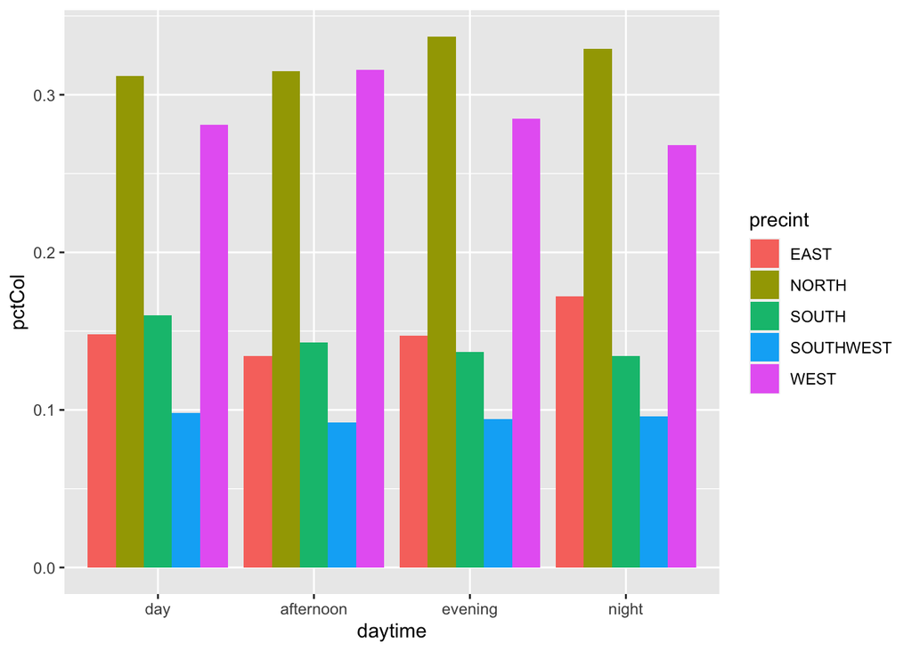

```r
barDodge= base1 +  geom_bar(stat="identity",
                            position ='dodge')
barDodge
```

The second is the **stack** style:

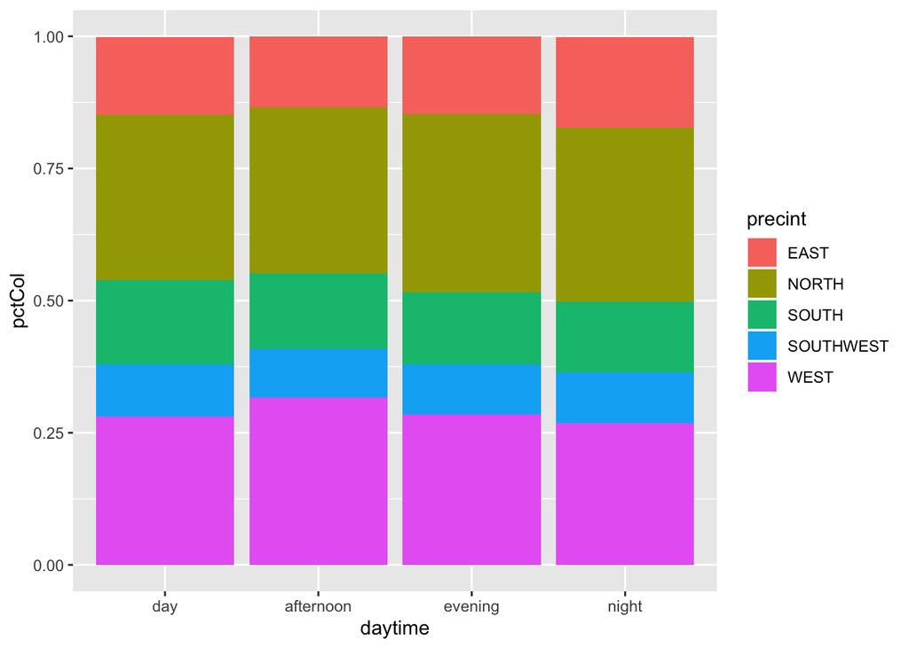

```r
barStacked = base1 + geom_bar(stat = "identity",
                              position = 'stack')#default
barStacked
```

The stacked version will help more than the dodged one as it reveals better the values in the contingency table, so we continue with adding some elements:

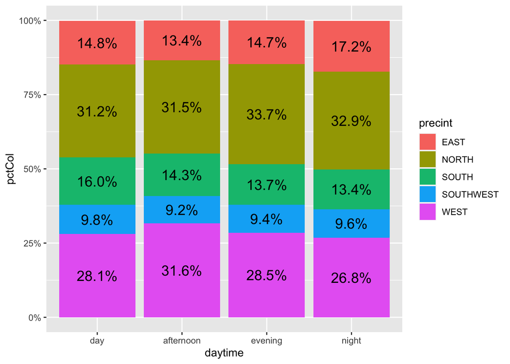

```r
library(scales)
barStacked= barStacked + geom_text(size = 5,# check below:
                             position = position_stack(vjust = 0.5),# center
                             aes(label=percent(pctCol,accuracy = 0.1)))# percent format

barStacked = barStacked + scale_y_continuous(labels = scales::percent)

barStacked
```

Since the precinct is nominal, and you see some marked differences along the rows, I can reorder its levels:

```r
PrecDaytiDF$precint=factor(PrecDaytiDF$precint,
                           levels=c("SOUTHWEST","EAST", "SOUTH","WEST","NORTH"))
```

Now, let me redo the last plot from the very beginning after the last change:

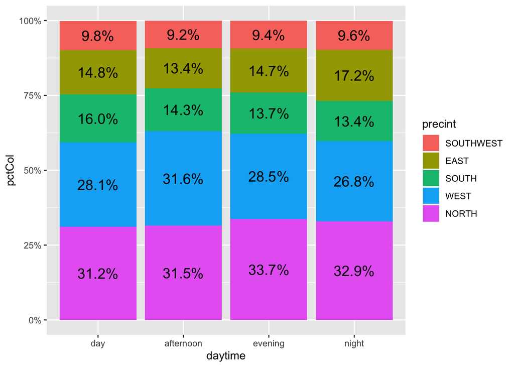

```r
base1=ggplot(data=PrecDaytiDF,
             aes(x=daytime, y=pctCol,
                 fill=precint))

barStacked = base1 + geom_bar(stat = "identity",
                              position = 'stack')
barStacked= barStacked + geom_text(size = 5,
                             position = position_stack(vjust = 0.5),
                             aes(label=percent(pctCol,accuracy = 0.1)))

barStacked = barStacked + scale_y_continuous(labels = scales::percent)

barStacked
```

Let me show you a more complex situation:

```r
# contingency table with many levels:

(CrimeDay=table(crime$crimecat,crime$Occurred.DayTime))
```

```
##
##                               day afternoon evening night
##   AGGRAVATED ASSAULT         3564      5366    4884  7501
##   ARSON                       196       167     191   486
##   BURGLARY                  24139     22288   14121 16082
##   CAR PROWL                 26740     38273   42595 34839
##   DISORDERLY CONDUCT           41        81      67    79
##   DUI                         706       939    2038  8522
##   FAMILY OFFENSE-NONVIOLENT  1748      2516    1217  1120
##   GAMBLE                        4         4       7     2
##   HOMICIDE                     41        46      49   131
##   LIQUOR LAW VIOLATION        112       491     410   606
##   LOITERING                    20        31      25     9
##   NARCOTIC                   2415      6416    3924  4109
##   PORNOGRAPHY                  65        53      17    31
##   PROSTITUTION                115       675    1425  1340
##   RAPE                        332       318     354   854
##   ROBBERY                    2584      4737    4139  5372
##   SEX OFFENSE-OTHER          1501      1759    1014  1776
##   THEFT                     38687     64868   38980 28410
##   TRESPASS                   4848      5184    2598  3289
##   WEAPON                      735      1445     947  1624
```

This contingency table has one categorical variables with several levels, let’s prepare turn the table into a data frame:

```r
#making a data frame from contingency table
CrimeDayDF=as.data.frame(CrimeDay)
#renaming:
names(CrimeDayDF)=c("crime","daytime","counts")
#marginal
CrimeDay_mgCol=prop.table(CrimeDay,margin = 2)
#adding marginal
CrimeDayDF$pctCol=as.data.frame(CrimeDay_mgCol)[,3]
# result for ggplot:
head(CrimeDayDF,20)
```

```
##                        crime daytime counts       pctCol
## 1         AGGRAVATED ASSAULT     day   3564 3.281980e-02
## 2                      ARSON     day    196 1.804905e-03
## 3                   BURGLARY     day  24139 2.222887e-01
## 4                  CAR PROWL     day  26740 2.462405e-01
## 5         DISORDERLY CONDUCT     day     41 3.775566e-04
## 6                        DUI     day    706 6.501340e-03
## 7  FAMILY OFFENSE-NONVIOLENT     day   1748 1.609680e-02
## 8                     GAMBLE     day      4 3.683479e-05
## 9                   HOMICIDE     day     41 3.775566e-04
## 10      LIQUOR LAW VIOLATION     day    112 1.031374e-03
## 11                 LOITERING     day     20 1.841739e-04
## 12                  NARCOTIC     day   2415 2.223900e-02
## 13               PORNOGRAPHY     day     65 5.985653e-04
## 14              PROSTITUTION     day    115 1.059000e-03
## 15                      RAPE     day    332 3.057287e-03
## 16                   ROBBERY     day   2584 2.379527e-02
## 17         SEX OFFENSE-OTHER     day   1501 1.382225e-02
## 18                     THEFT     day  38687 3.562568e-01
## 19                  TRESPASS     day   4848 4.464376e-02
## 20                    WEAPON     day    735 6.768392e-03
```

Sometime, a simple contingency table does not need to be plotted in order to reveal salient relationships; bt in this case we need visual help to discover some association.

Last time, we turn the contingency table into a stacked barplot, let’s try again:

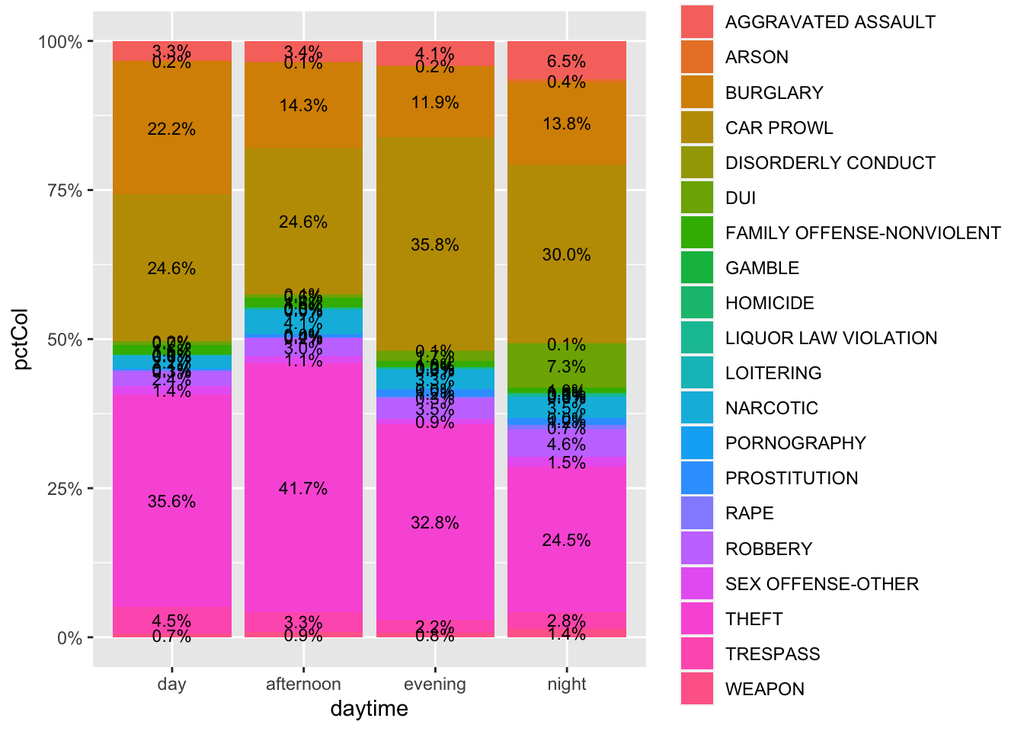

```r
# bad idea
base2=ggplot(data=CrimeDayDF,
             aes(x=daytime,y=pctCol,fill=crime))
base2=base2 + geom_bar(stat = "identity", position = 'fill') +
        geom_text(size = 3,
                  position = position_stack(vjust = 0.5),
                  aes(label=percent(pctCol,accuracy = 0.1)))
barStacked2 = base2 + scale_y_continuous(labels = scales::percent)

barStacked2
```

This plot will need a lot of work, so using the previous plots may not be a good strategy.

A first option you may have is to reproduce the table:

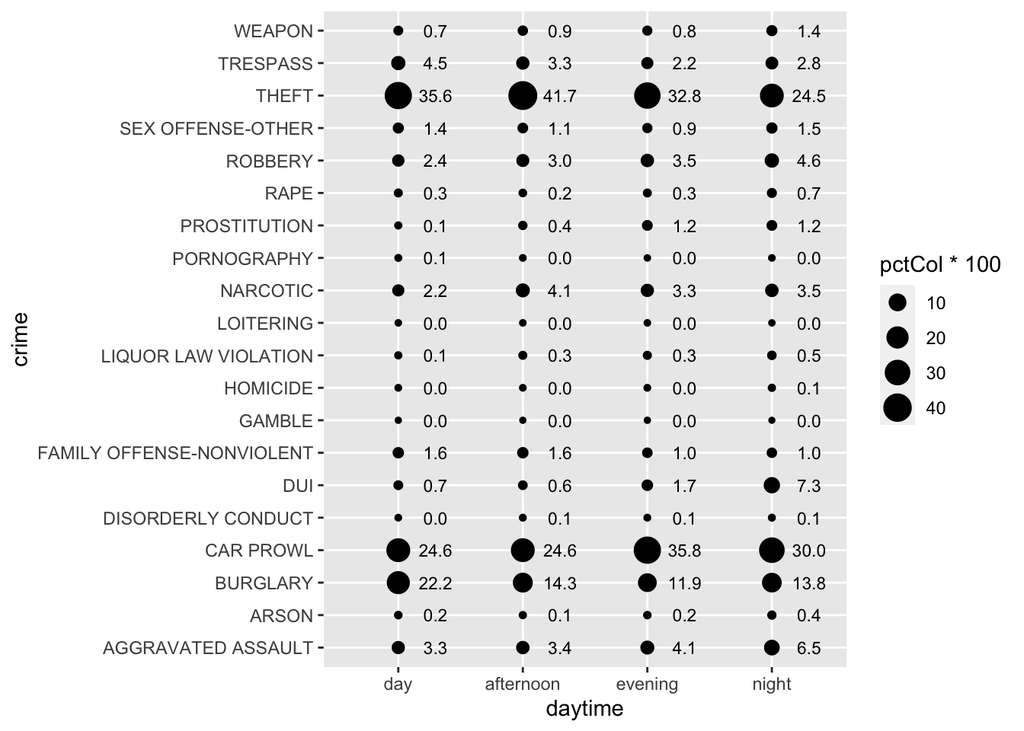

```r
#new base
base3 = ggplot(CrimeDayDF, aes(x=daytime,y=crime))
# plot value as point, size by value of percent
tablePlot = base3 + geom_point(aes(size = pctCol*100))
# add value of Percent as label
tablePlot = tablePlot + geom_text(aes(label = percent(pctCol,
                                                      accuracy = 0.1,
                                                      suffix = "")),#no %
                                  nudge_x = 0.3,
                                  size=3)
tablePlot
```

…some more work:

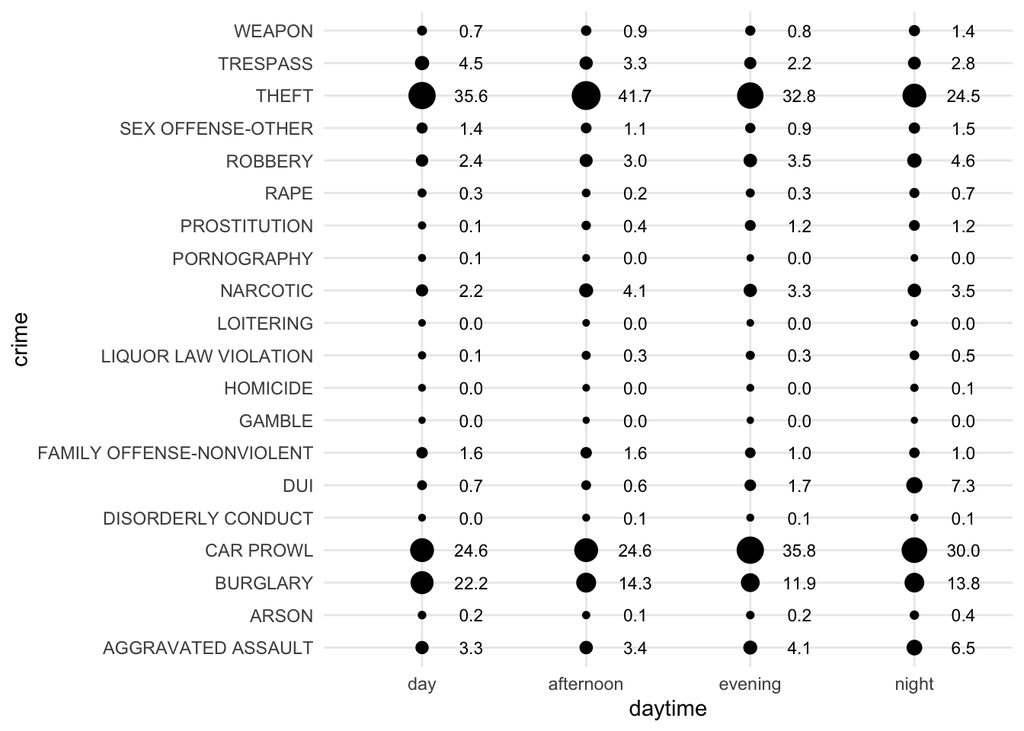

```r
# improving previous plot

tablePlot = tablePlot + theme_minimal() # less ink
tablePlot = tablePlot + theme(legend.position="none") # no legend
tablePlot
```

The plot looks nice, but unless the differences are clearly cut, you may see more noise than information, which distracts and delays decision making. Keep in mind that *length* of bars are easier to compare than circle *areas*. Let;s go for a dodged barplot, but with the help of **facets**:

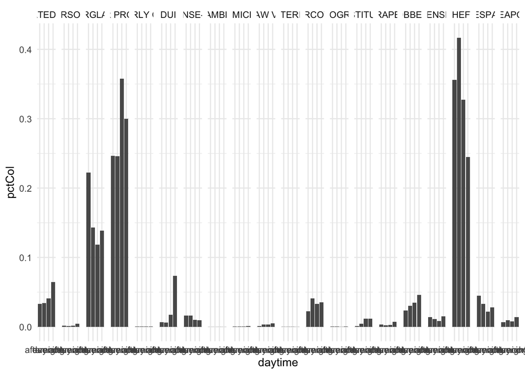

```r
# as usual for barplot (less info than base1)
base4 = ggplot(CrimeDayDF, aes(x = daytime, y = pctCol ) )

#the bars
bars  = base4 + geom_bar( stat = "identity" ) + theme_minimal()

# bar per day time with 'facet'
barsFa = bars + facet_grid(~ crime)

barsFa
```

In the previous plot we respected the XY relationship, but this does not look like the crosstable; let’s solve that:

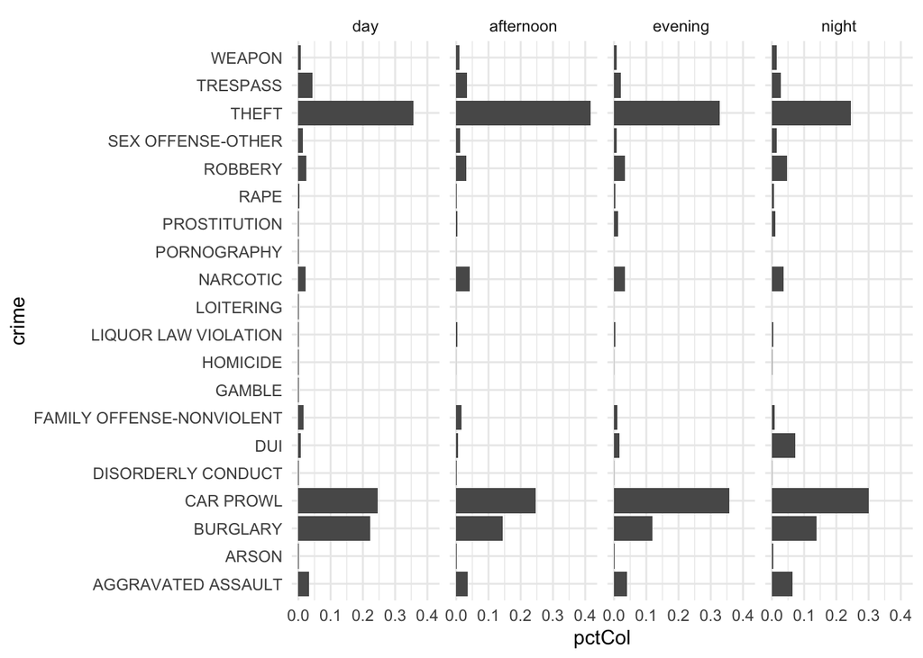

```r
# change x to our early Y
base4 = ggplot(CrimeDayDF, aes(x = crime, y = pctCol ) )
bars  = base4 + geom_bar( stat = "identity" ) + theme_minimal()
barsFa = bars + facet_grid(~ daytime)  # X
# trick
barsFa + coord_flip()
```

The type of crime is not ordinal, then we could **reorder** the bars:

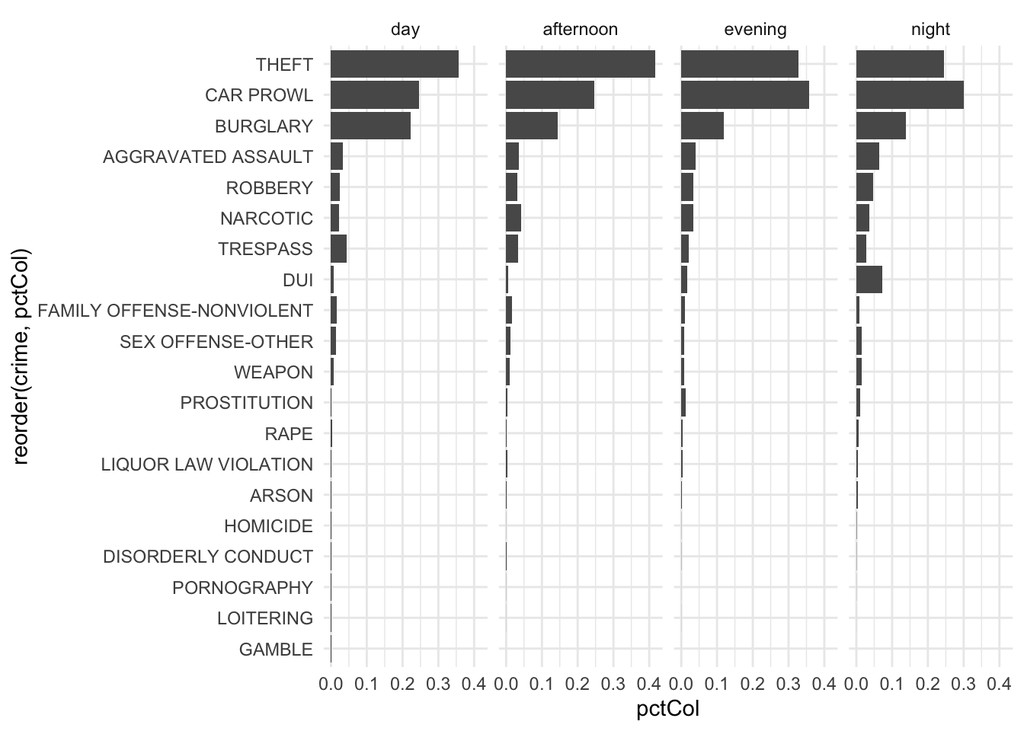

```r
# introducing "reorder""

#crime ordered by %
# new base
baseRE  = ggplot(CrimeDayDF,
                 aes(x = reorder(crime, pctCol), #here
                     y = pctCol ) ) + theme_minimal()

barsRE = baseRE + geom_bar( stat = "identity" )
barsREFa = barsRE + facet_grid( ~ daytime)
barsREFa= barsREFa + coord_flip()


barsREFa
```

Let’s annotate:

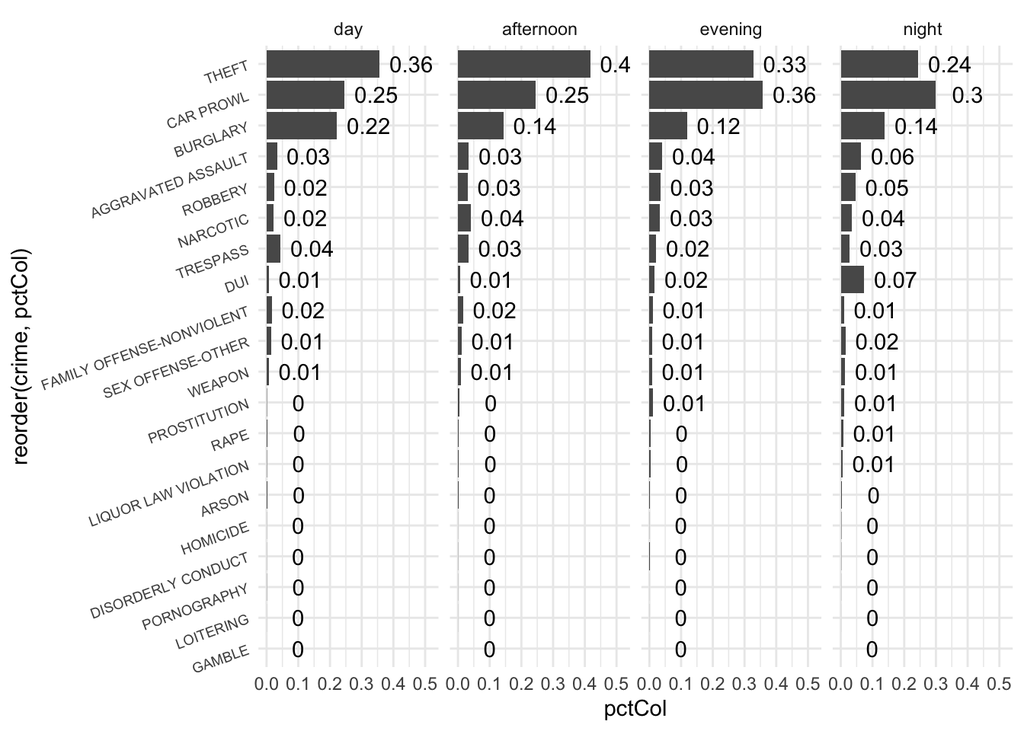

```r
barsREFa + theme(axis.text.y = element_text(size=7,angle = 20)) +
           geom_text(aes(label=round(pctCol,2)),
                     nudge_y = 0.1)
```

Let’s improve the annotation:

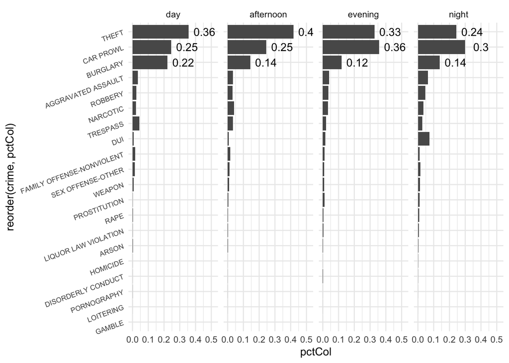

```r
barsREFa + theme(axis.text.y = element_text(size=7,angle = 20)) +
           geom_text(aes(label=ifelse(pctCol>0.1,# condition to annotate
                                      round(pctCol,2),"")),
                     nudge_y = 0.1)
```

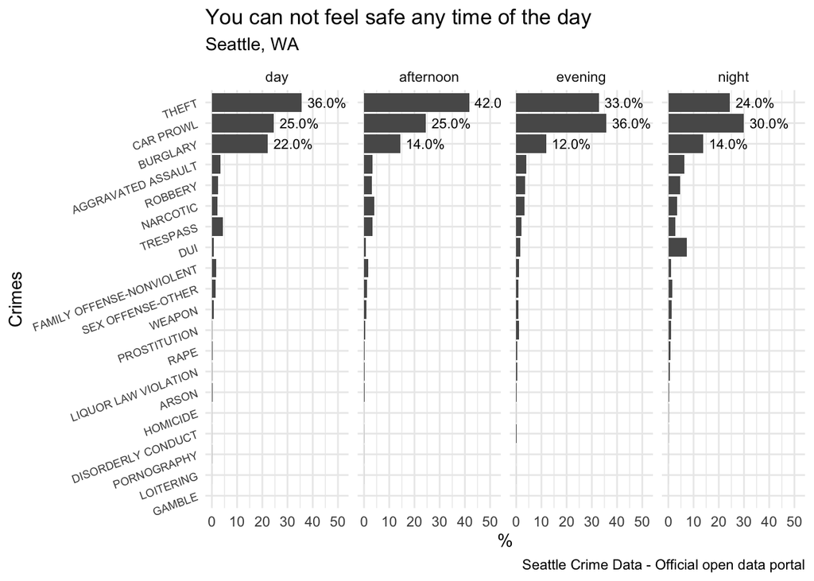

```r
barsREFa + theme(axis.text.y = element_text(size=7,angle = 20)) +
           geom_text(aes(label=ifelse(pctCol>0.1,# condition to annotate
                                      scales::percent(round(pctCol,2)),"")),
                     nudge_y = 0.1,size=3) +
           scale_y_continuous(labels = percent_format(accuracy = 1,suffix="")) +
    labs(title= "You can not feel safe any time of the day",
         subtitle = "Seattle, WA",
         caption = "Seattle Crime Data - Official open data portal",
         x="Crimes",y="%")
```

You can try playing with color gradient:

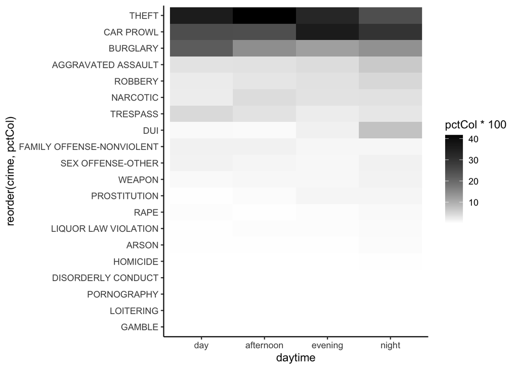

```r
# heatplot
base  = ggplot(CrimeDayDF, aes(x = daytime,
                               y = reorder(crime, pctCol),
                               fill = pctCol*100))
heat = base +  geom_tile()

# grey intensity
heat = heat +scale_fill_gradient(low = "white",
                                   high = "black")
heat = heat + theme_classic()

heat
```

Some little changes:

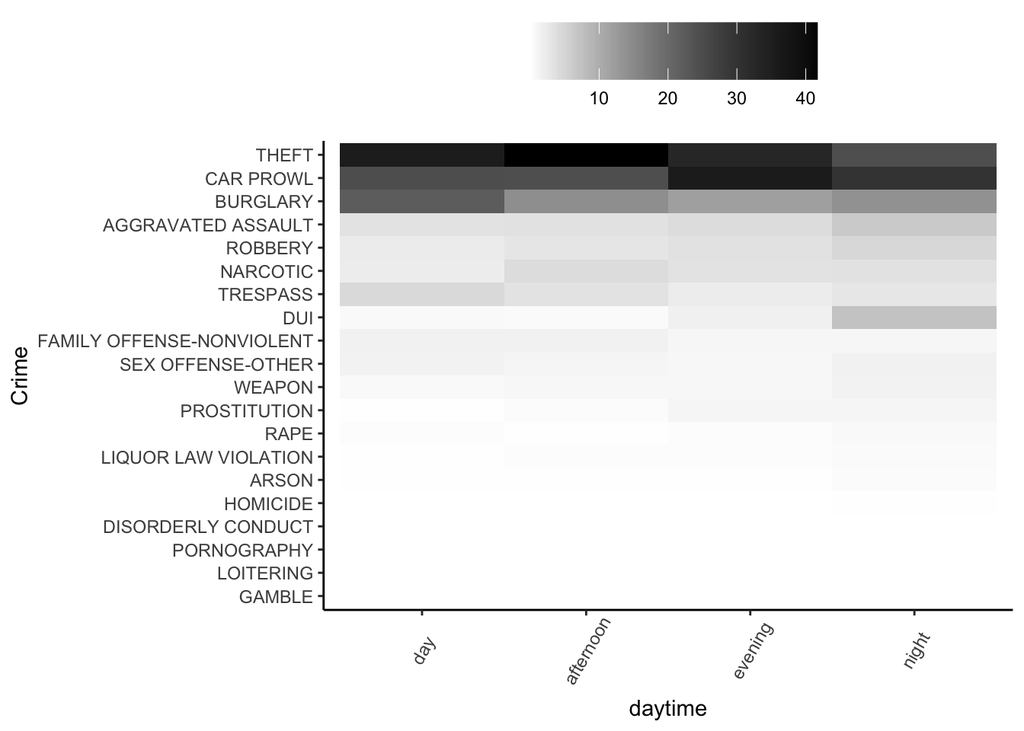

```r
# improving heat plot

heat = heat + labs(y="Crime", "Time of day")
heat = heat + theme(axis.text.x = element_text(angle = 60,
                                               vjust = 0.6),
                      legend.title = element_blank(), #no leg. title
                      legend.position="top",
                      legend.direction="horizontal",
                      legend.key.width=unit(1, "cm"),
                      legend.key.height=unit(1, "cm"))

heat
```

You can try a different palette:

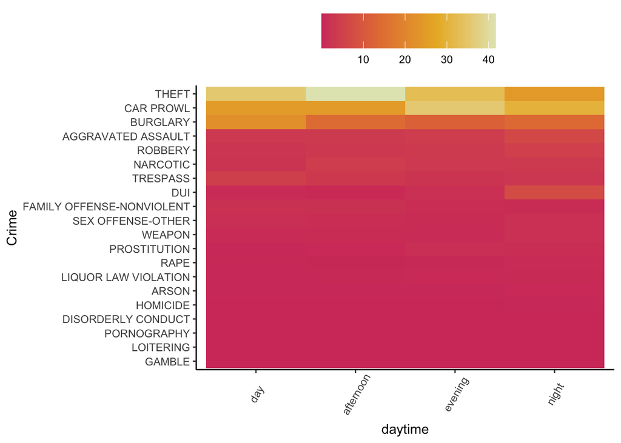

```r
# heatplot
base  = ggplot(CrimeDayDF, aes(x = daytime,
                               y = reorder(crime, pctCol),
                               fill = pctCol*100))
heat = base +  geom_tile()

# CHANGING COLORS
heat = heat +scale_fill_gradientn(colours = colorspace::heat_hcl(4))
heat = heat + theme_classic()

heat = heat + labs(y="Crime", "Time of day")
heat = heat + theme(axis.text.x = element_text(angle = 60,
                                               vjust = 0.6),
                      legend.title = element_blank(), #no leg. title
                      legend.position="top",
                      legend.direction="horizontal",
                      legend.key.width=unit(1, "cm"),
                      legend.key.height=unit(1, "cm"))

heat
```

And alter the direction of the color:

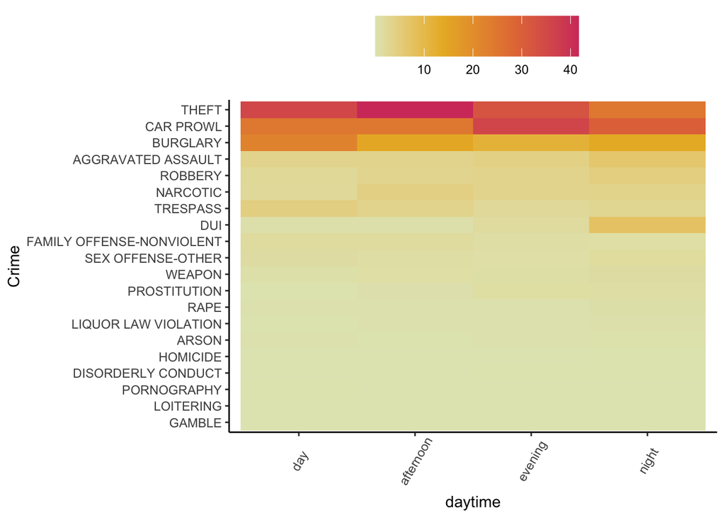

```r
# heatplot
base  = ggplot(CrimeDayDF, aes(x = daytime,
                               y = reorder(crime, pctCol),
                               fill = pctCol*100))
heat = base +  geom_tile()

# ALTERING DIRECTION
heat = heat +scale_fill_gradientn(colours = rev(colorspace::heat_hcl(4)))
heat = heat + theme_classic()

heat = heat + labs(y="Crime", "Time of day")
heat = heat + theme(axis.text.x = element_text(angle = 60,
                                               vjust = 0.6),
                      legend.title = element_blank(), #no leg. title
                      legend.position="top",
                      legend.direction="horizontal",
                      legend.key.width=unit(1, "cm"),
                      legend.key.height=unit(1, "cm"))

heat
```

I think this may not be better than our last barplot, but it may work in other situations.